# Spillover flows between HICs and LMICs (excl. China)

Innovation Strategy Explorer — insights

2026-05-06

## What this note shows

How much per-innovation spillover value flows between High-Income Countries (HICs) and LMICs (excl. China) — and how it varies by technology and by where the innovation was filed.

We run the same three views three times:

1. **No restriction** — every patent family the app’s database knows about, granted or not, single- or multi-application.
2. **Granted families only** — the same sample as the original public-facing version of this note.
3. **`docdb_family_size` > 1** — restricting to multi-application patent families (PATSTAT `docdb_family_size >= 2`), which filters out one-off applications and tends to focus the sample on technologies firms commit further investment to.

In figures 1 and 2, an overlaid **circle marker** reports the **LMIC share of total innovation in each category** (LMIC-origin family count ÷ all-origin family count) on a secondary axis.

## Data source

CSVs from the public Country Explorer tab of https://mondpanther-iseapp2.share.connect.posit.cloud/: per sample, two destination flows × three country filters = 6 CSVs. Missing CSVs are fetched automatically via headless Chrome (`chromote`) — the patent database is never accessed directly.

# Sample 1: no restriction

Every family in the app’s database, regardless of grant status or family size. This is the broadest universe — useful as a baseline before applying the granted / multi-application filters in the next two sections.

App-view URL templates: LMIC->HIC | HIC->HIC | LMIC->LMIC | HIC->LMIC

## Figure 1 (no restriction) — Spillovers to HICs

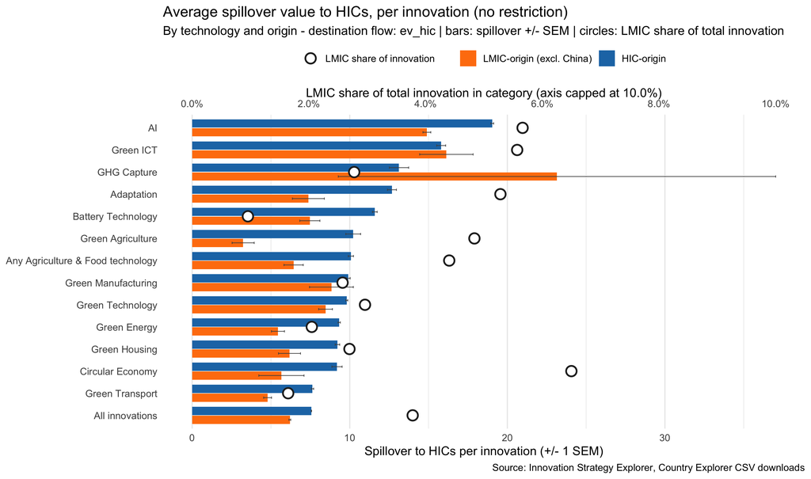

## Figure 2 (no restriction) — Spillovers to LMICs (excl. China)

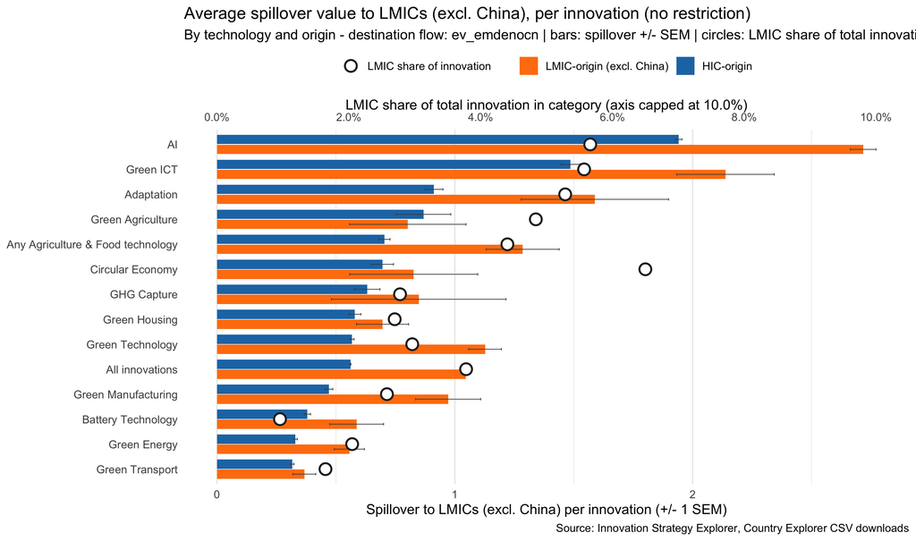

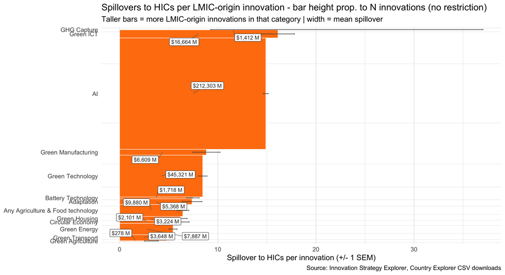

## Figure 4 (no restriction) — Average citation count per innovation

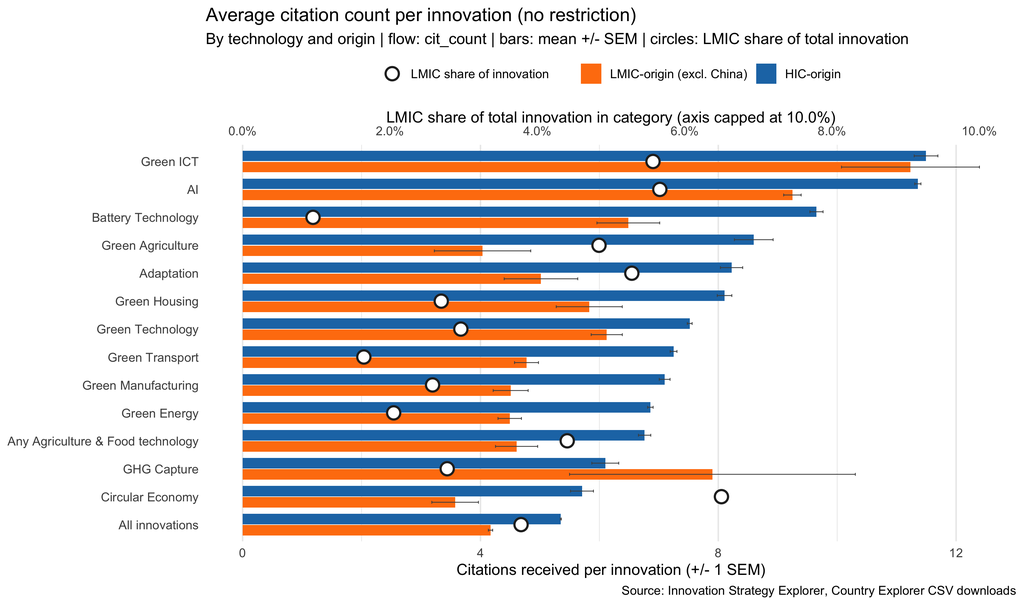

## Summary table (no restriction)

Per-innovation spillover means by destination, technology, and origin (no restriction).

| Destination | Technology | Mean LMIC->dest | Mean HIC->dest | SEM LMIC->dest | SEM HIC->dest | N LMIC-origin | N HIC-origin | Ratio LMIC / HIC |
| --- | --- | --- | --- | --- | --- | --- | --- | --- |
| HICs | AI | 14.89 | 19.04 | 0.25 | 0.09 | 14255 | 215875 | 0.78 |
| HICs | Green ICT | 16.13 | 15.80 | 1.70 | 0.28 | 1033 | 15313 | 1.02 |
| HICs | GHG Capture | 23.15 | 13.12 | 13.88 | 0.61 | 61 | 2108 | 1.76 |
| HICs | Adaptation | 7.37 | 12.68 | 1.01 | 0.28 | 728 | 12449 | 0.58 |
| HICs | Battery Technology | 7.47 | 11.59 | 0.64 | 0.15 | 230 | 21894 | 0.64 |
| HICs | Green Agriculture | 3.23 | 10.22 | 0.70 | 0.47 | 86 | 1597 | 0.32 |
| HICs | Any Agriculture & Food technology | 6.44 | 10.07 | 0.61 | 0.17 | 1535 | 31059 | 0.64 |
| HICs | Green Manufacturing | 8.84 | 9.90 | 1.39 | 0.13 | 748 | 26279 | 0.89 |
| HICs | Green Technology | 8.46 | 9.81 | 0.44 | 0.06 | 5355 | 163338 | 0.86 |
| HICs | Green Energy | 5.44 | 9.33 | 0.41 | 0.07 | 1449 | 63543 | 0.58 |
| HICs | Green Housing | 6.18 | 9.22 | 0.70 | 0.15 | 522 | 17123 | 0.67 |
| HICs | Circular Economy | 5.66 | 9.19 | 1.43 | 0.32 | 371 | 4975 | 0.62 |
| HICs | Green Transport | 4.79 | 7.63 | 0.25 | 0.07 | 762 | 44416 | 0.63 |
| HICs | All innovations | 6.20 | 7.57 | 0.06 | 0.01 | 105845 | 2460089 | 0.82 |
| LMICs (excl. China) | AI | 2.72 | 1.94 | 0.05 | 0.01 | 14255 | 215875 | 1.40 |
| LMICs (excl. China) | Green ICT | 2.14 | 1.49 | 0.21 | 0.04 | 1033 | 15313 | 1.44 |
| LMICs (excl. China) | Adaptation | 1.59 | 0.91 | 0.31 | 0.04 | 728 | 12449 | 1.74 |
| LMICs (excl. China) | Green Agriculture | 0.80 | 0.87 | 0.25 | 0.11 | 86 | 1597 | 0.92 |
| LMICs (excl. China) | Any Agriculture & Food technology | 1.29 | 0.70 | 0.15 | 0.02 | 1535 | 31059 | 1.83 |
| LMICs (excl. China) | Circular Economy | 0.83 | 0.70 | 0.27 | 0.05 | 371 | 4975 | 1.19 |
| LMICs (excl. China) | GHG Capture | 0.85 | 0.63 | 0.37 | 0.05 | 61 | 2108 | 1.34 |
| LMICs (excl. China) | Green Housing | 0.70 | 0.58 | 0.11 | 0.03 | 522 | 17123 | 1.20 |
| LMICs (excl. China) | Green Technology | 1.13 | 0.57 | 0.07 | 0.01 | 5355 | 163338 | 1.98 |
| LMICs (excl. China) | All innovations | 1.05 | 0.56 | 0.01 | 0.00 | 105845 | 2460089 | 1.86 |
| LMICs (excl. China) | Green Manufacturing | 0.97 | 0.47 | 0.14 | 0.02 | 748 | 26279 | 2.06 |
| LMICs (excl. China) | Battery Technology | 0.59 | 0.38 | 0.11 | 0.01 | 230 | 21894 | 1.55 |
| LMICs (excl. China) | Green Energy | 0.56 | 0.33 | 0.06 | 0.01 | 1449 | 63543 | 1.69 |
| LMICs (excl. China) | Green Transport | 0.37 | 0.32 | 0.05 | 0.01 | 762 | 44416 | 1.16 |

# Sample 2: granted families only

App-view URL templates: LMIC->HIC | HIC->HIC | LMIC->LMIC | HIC->LMIC

## Figure 1 (granted) — Spillovers to HICs

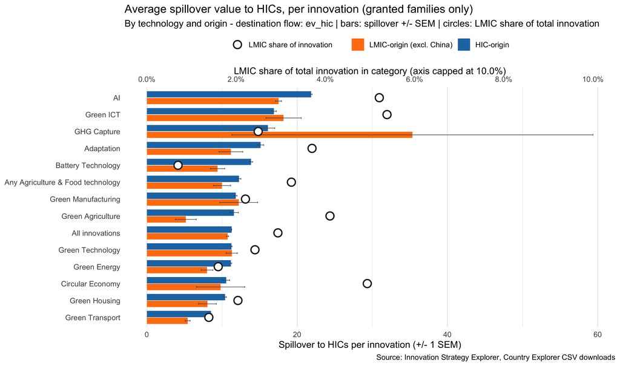

## Figure 2 (granted) — Spillovers to LMICs (excl. China)

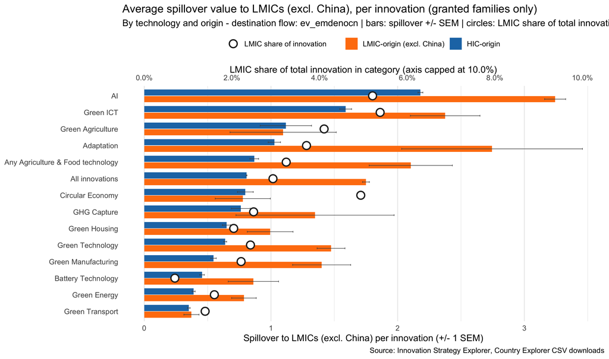

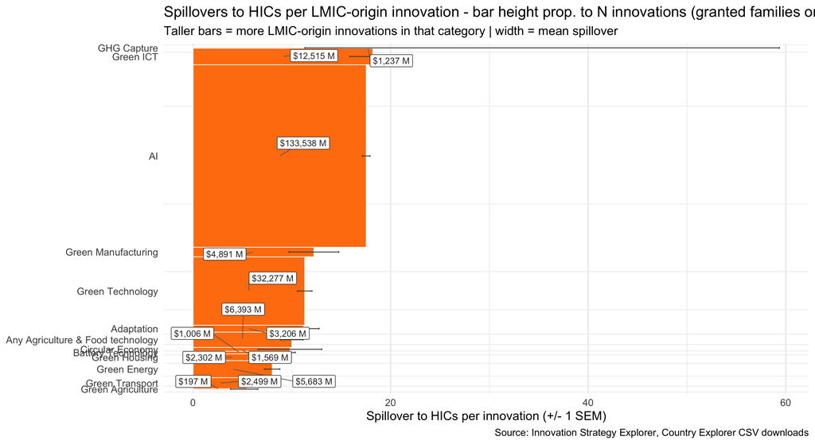

## Figure 4 (granted) — Average citation count per innovation

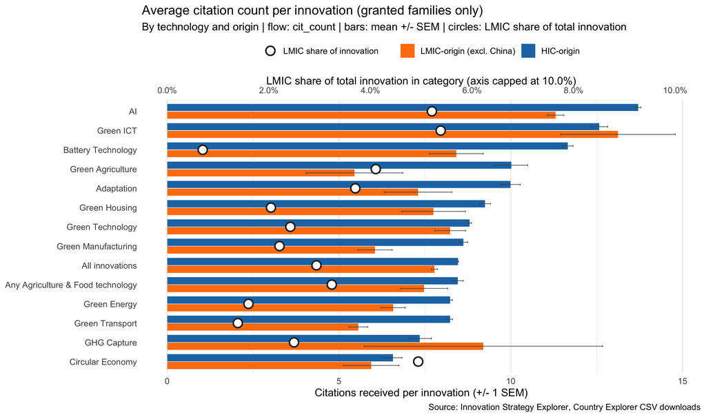

## Summary table (granted)

Per-innovation spillover means by destination, technology, and origin (granted families only).

| Destination | Technology | Mean LMIC->dest | Mean HIC->dest | SEM LMIC->dest | SEM HIC->dest | N LMIC-origin | N HIC-origin | Ratio LMIC / HIC |
| --- | --- | --- | --- | --- | --- | --- | --- | --- |
| HICs | AI | 17.52 | 21.85 | 0.39 | 0.14 | 7622 | 126161 | 0.80 |
| HICs | Green ICT | 18.19 | 16.89 | 2.35 | 0.33 | 688 | 10899 | 1.08 |
| HICs | GHG Capture | 35.34 | 16.10 | 24.02 | 0.92 | 35 | 1348 | 2.20 |
| HICs | Adaptation | 11.17 | 15.12 | 1.58 | 0.43 | 287 | 7096 | 0.74 |
| HICs | Battery Technology | 9.41 | 13.85 | 0.94 | 0.21 | 107 | 14087 | 0.68 |
| HICs | Any Agriculture & Food technology | 9.99 | 12.25 | 1.15 | 0.25 | 640 | 17868 | 0.82 |
| HICs | Green Manufacturing | 12.23 | 11.82 | 2.52 | 0.18 | 400 | 16391 | 1.03 |
| HICs | Green Agriculture | 5.17 | 11.58 | 1.39 | 0.59 | 38 | 841 | 0.45 |
| HICs | All innovations | 10.75 | 11.27 | 0.13 | 0.02 | 36813 | 1123026 | 0.95 |
| HICs | Green Technology | 11.30 | 11.25 | 0.74 | 0.08 | 2857 | 107500 | 1.00 |
| HICs | Green Energy | 8.00 | 11.19 | 0.78 | 0.10 | 710 | 40092 | 0.72 |
| HICs | Circular Economy | 9.81 | 10.55 | 3.22 | 0.46 | 160 | 2849 | 0.93 |
| HICs | Green Housing | 8.05 | 10.39 | 1.19 | 0.19 | 286 | 12426 | 0.77 |
| HICs | Green Transport | 5.42 | 8.52 | 0.33 | 0.10 | 461 | 32089 | 0.64 |
| LMICs (excl. China) | AI | 3.24 | 2.18 | 0.08 | 0.02 | 7622 | 126161 | 1.49 |
| LMICs (excl. China) | Green ICT | 2.38 | 1.59 | 0.27 | 0.05 | 688 | 10899 | 1.49 |
| LMICs (excl. China) | Green Agriculture | 1.10 | 1.12 | 0.42 | 0.20 | 38 | 841 | 0.98 |
| LMICs (excl. China) | Adaptation | 2.75 | 1.03 | 0.71 | 0.05 | 287 | 7096 | 2.67 |
| LMICs (excl. China) | Any Agriculture & Food technology | 2.10 | 0.87 | 0.33 | 0.03 | 640 | 17868 | 2.42 |
| LMICs (excl. China) | All innovations | 1.75 | 0.81 | 0.03 | 0.00 | 36813 | 1123026 | 2.17 |
| LMICs (excl. China) | Circular Economy | 0.78 | 0.80 | 0.22 | 0.06 | 160 | 2849 | 0.97 |
| LMICs (excl. China) | GHG Capture | 1.35 | 0.76 | 0.62 | 0.07 | 35 | 1348 | 1.77 |
| LMICs (excl. China) | Green Housing | 0.99 | 0.65 | 0.18 | 0.03 | 286 | 12426 | 1.53 |
| LMICs (excl. China) | Green Technology | 1.47 | 0.64 | 0.11 | 0.01 | 2857 | 107500 | 2.31 |
| LMICs (excl. China) | Green Manufacturing | 1.40 | 0.55 | 0.23 | 0.02 | 400 | 16391 | 2.56 |
| LMICs (excl. China) | Battery Technology | 0.86 | 0.46 | 0.20 | 0.02 | 107 | 14087 | 1.89 |
| LMICs (excl. China) | Green Energy | 0.79 | 0.39 | 0.10 | 0.01 | 710 | 40092 | 2.02 |
| LMICs (excl. China) | Green Transport | 0.37 | 0.35 | 0.06 | 0.01 | 461 | 32089 | 1.06 |

# Sample 3: `docdb_family_size` > 1

App-view URL templates: LMIC->HIC | HIC->HIC | LMIC->LMIC | HIC->LMIC

## Figure 1 (fam_size > 1) — Spillovers to HICs

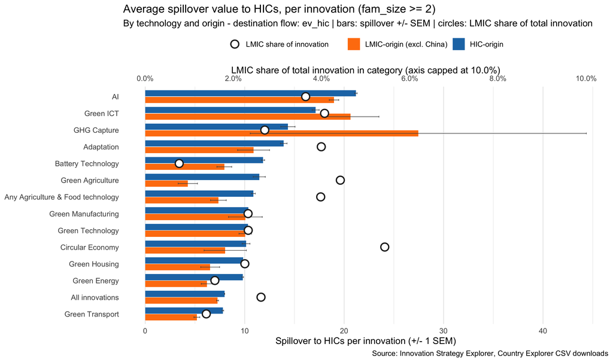

## Figure 2 (fam_size > 1) — Spillovers to LMICs (excl. China)

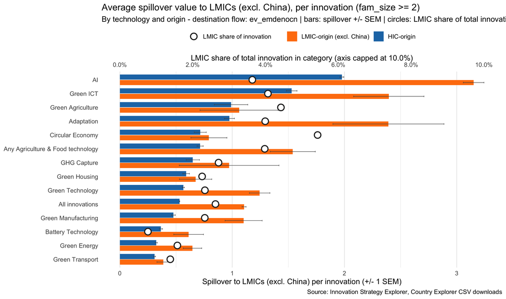

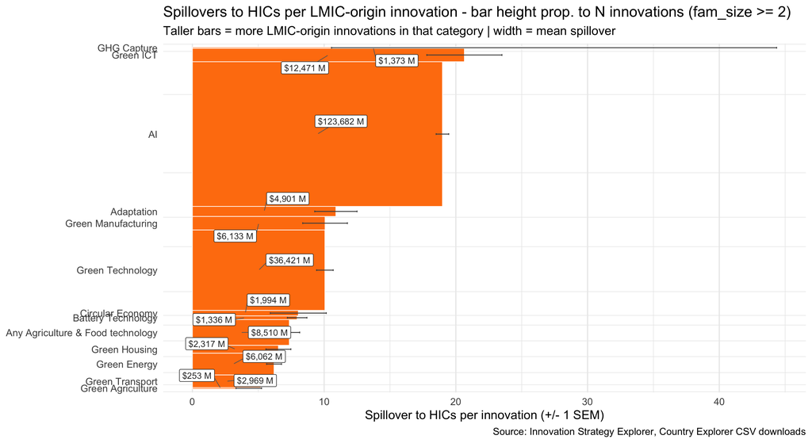

## Figure 4 (fam_size > 1) — Average citation count per innovation

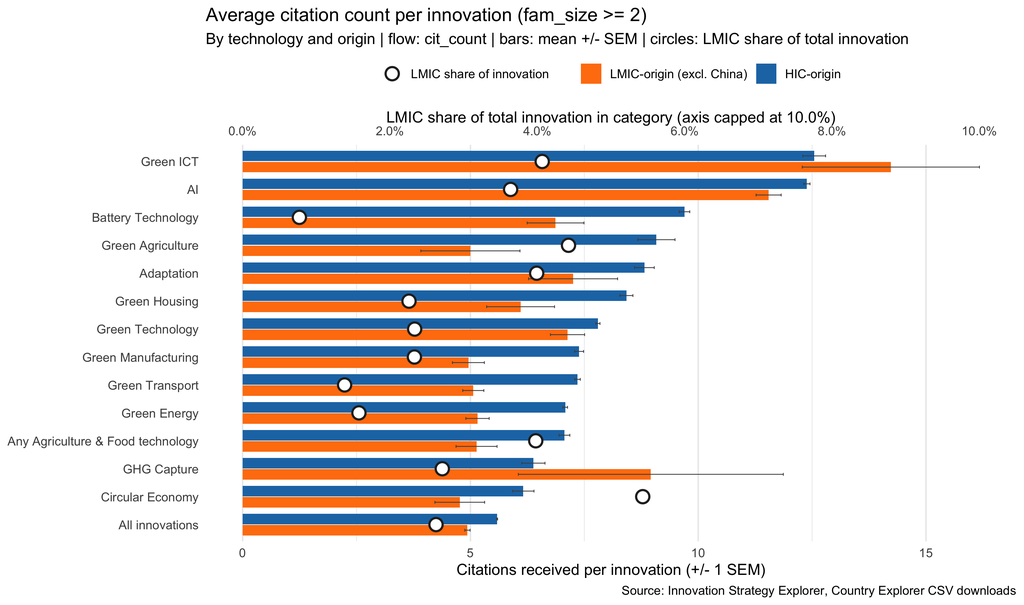

## Summary table (fam_size > 1)

Per-innovation spillover means by destination, technology, and origin (fam_size >= 2).

| Destination | Technology | Mean LMIC->dest | Mean HIC->dest | SEM LMIC->dest | SEM HIC->dest | N LMIC-origin | N HIC-origin | Ratio LMIC / HIC |
| --- | --- | --- | --- | --- | --- | --- | --- | --- |
| HICs | AI | 18.98 | 21.19 | 0.48 | 0.12 | 6516 | 150889 | 0.90 |
| HICs | Green ICT | 20.65 | 17.13 | 2.85 | 0.35 | 604 | 11973 | 1.21 |
| HICs | GHG Capture | 27.46 | 14.35 | 16.90 | 0.72 | 50 | 1761 | 1.91 |
| HICs | Adaptation | 10.89 | 13.92 | 1.61 | 0.33 | 450 | 10241 | 0.78 |
| HICs | Battery Technology | 7.95 | 11.84 | 0.74 | 0.16 | 168 | 19751 | 0.67 |
| HICs | Green Agriculture | 4.28 | 11.46 | 0.97 | 0.61 | 59 | 1186 | 0.37 |
| HICs | Any Agriculture & Food technology | 7.36 | 10.87 | 0.79 | 0.19 | 1157 | 25791 | 0.68 |
| HICs | Green Manufacturing | 10.07 | 10.37 | 1.70 | 0.14 | 609 | 23546 | 0.97 |
| HICs | Green Technology | 10.06 | 10.32 | 0.63 | 0.07 | 3621 | 139611 | 0.97 |
| HICs | Circular Economy | 8.04 | 10.14 | 2.13 | 0.39 | 248 | 3978 | 0.79 |
| HICs | Green Housing | 6.53 | 9.84 | 0.95 | 0.17 | 355 | 13772 | 0.66 |
| HICs | Green Energy | 6.20 | 9.81 | 0.57 | 0.08 | 978 | 55489 | 0.63 |
| HICs | All innovations | 7.27 | 7.98 | 0.09 | 0.02 | 58256 | 1935128 | 0.91 |
| HICs | Green Transport | 5.19 | 7.81 | 0.30 | 0.08 | 572 | 39607 | 0.66 |
| LMICs (excl. China) | AI | 3.15 | 1.98 | 0.09 | 0.02 | 6516 | 150889 | 1.59 |
| LMICs (excl. China) | Green ICT | 2.39 | 1.53 | 0.31 | 0.05 | 604 | 11973 | 1.57 |
| LMICs (excl. China) | Green Agriculture | 1.06 | 0.99 | 0.35 | 0.15 | 59 | 1186 | 1.07 |
| LMICs (excl. China) | Adaptation | 2.39 | 0.98 | 0.49 | 0.04 | 450 | 10241 | 2.45 |
| LMICs (excl. China) | Circular Economy | 0.79 | 0.72 | 0.16 | 0.05 | 248 | 3978 | 1.11 |
| LMICs (excl. China) | Any Agriculture & Food technology | 1.54 | 0.71 | 0.20 | 0.03 | 1157 | 25791 | 2.15 |
| LMICs (excl. China) | GHG Capture | 0.97 | 0.65 | 0.44 | 0.06 | 50 | 1761 | 1.50 |
| LMICs (excl. China) | Green Housing | 0.67 | 0.59 | 0.14 | 0.03 | 355 | 13772 | 1.14 |
| LMICs (excl. China) | Green Technology | 1.24 | 0.56 | 0.09 | 0.01 | 3621 | 139611 | 2.20 |
| LMICs (excl. China) | All innovations | 1.11 | 0.53 | 0.02 | 0.00 | 58256 | 1935128 | 2.08 |
| LMICs (excl. China) | Green Manufacturing | 1.10 | 0.48 | 0.17 | 0.02 | 609 | 23546 | 2.31 |
| LMICs (excl. China) | Battery Technology | 0.61 | 0.37 | 0.13 | 0.01 | 168 | 19751 | 1.68 |
| LMICs (excl. China) | Green Energy | 0.65 | 0.32 | 0.08 | 0.01 | 978 | 55489 | 2.00 |
| LMICs (excl. China) | Green Transport | 0.39 | 0.31 | 0.06 | 0.01 | 572 | 39607 | 1.25 |

## Notes & caveats

- Bars in Figures 1 and 2 use the same destination flow within each figure, so the levels are directly comparable within a technology.
- The sample size column `innos` is **not** the same across origins: LMIC innovator pools are smaller, so their SEMs are typically larger. Treat any orange/blue gap inside a large SEM with caution.
- The three top-level samples are: (1) no restriction (the underlying universe), (2) “granted families only” UI checkbox, (3) “multi-application families only” checkbox (i.e. PATSTAT `docdb_family_size >= 2`). Samples 2 and 3 are **not** subsets of each other — a granted family can be a single application, and a multi-application family need not be granted.
- The origin-country filter selects patents filed from the relevant country group; downstream-citing patents can come from anywhere in the world, but only destination-country citations count toward the `ev_*` flow.
- Data acquisition uses only the app’s public CSV-download endpoint (via `chromote`) — the patent database is never accessed directly.

Rendered 2026-05-06 07:34 BST · app version `unknown`